# wetlandmapR Example

Deepa Filatow, Gillian Harvey, Alexandre Bevington, Hunter Gleason

Using example data provided with the package the following vignette demonstrates the use of the wetlandmapR package to classify wetlands using terrain derivatives and external inputs such as satellite imagery. This document is written to serve as a reference for performing similar classification in any area of interest.

## Using the wetlandmapr Docker …

A Docker image based on the [**rocker/geospatial:4.1.2**](https://hub.docker.com/r/rocker/geospatial) image has been assembled for running the [wetlandmapR package](https://github.com/bcgov/wetlandmapR) package. Please see the [Docker Install](https://docs.docker.com/engine/install/) page for platform specific guidance on installing Docker. Assuming a local installation of Docker is in place, the [huntgdok/wetlandmapr:latest](https://hub.docker.com/r/huntgdok/wetlandmapr) Docker image can be downloaded by passing the command below from your terminal or command prompt:

```bash
docker pull huntgdok/wetlandmapr:latest
```

once the image has been successfully pulled, it can be run from the terminal or command prompt using the docker run call as shown below

```bash
docker run -e PASSWORD=APassword -e ROOT=TRUE -p 8787:8787 -v "/c/User/Desktop/Data:/home/rstudio/Data" --rm huntgdok/wetlandmapr:latest
```

where *APassword* is any password you want to use to log into *rocker*. To use with sudo privileges, add *-e ROOT=TRUE* to the docker run call as shown above. The *-v* flag in the Docker run call above mounts a volume on the host machine, in this case */c/User/Desktop/Data* on a Windows machine, to a directory called *Data* on the Docker container, see [Use Volumes](https://docs.docker.com/storage/volumes/) for more information about mounting volumes. To view the running docker, go to the local URL [localhost](http://localhost:8787) *http://localhost:8787* in your internet browser. When prompted for a *username* and *password*, supply *rstudio* as a username, and the password that you set with the *docker run* call. You should then have a R-Studio session running with all the R and third party dependencies required for running the [**wetlandmapR**](https://github.com/bcgov/wetlandmapR) package.

Alternatively, the package can be run locally assuming all of the required dependencies are installed.

## Load required packages …

```r
library('wetlandmapR')
library('terra')
library('sf')
library('tools')
library('bcmaps')
library('ggplot2')
library('RStoolbox')
library('RSAGA')
library('doParallel')
library('parallel')
```

## Creating elevation derivatives …

The following lines of code define an output directory for the terrain derivatives, load in an example digital elevation model (DEM) from the [wetlandmapR package](https://github.com/bcgov/wetlandmapR), and calls the *wetlandmapR::create_dem_products* function to generate terrain derivatives using [SAGA-GIS](http://www.saga-gis.org/) and RSAGA. These terrain derivatives will be used to predict the wetland classes. As a pre-processing step, *wetlandmapR::create_dem_products* first hydrologically conditions the DEM by filling any sinks, a binary sinks layer is output under the name *SINKS.sgrd*. Optionally, if a stream vector is provided (*stream_vec*) it may be burned into the DEM by a distance (*burn_val*) in meters defined by the user. The terrain derivative layers specified by *products* (default all) are output to the directory provided to *outdir*. Using the *param_vect* and *param_values* parameters additional options can be provided to the SAGA modules, such as shown for the SAGA-GIS *TPI* module below.

```r
#Establish a RSAGA environment
env<-rsaga.env(parallel = T)

#Specify a output directory, we'll use the temporary directory for this example
out_dir<-paste(tempdir(),"/wetlandmapR_expl",sep="")
dir.create(out_dir)

#Load a example digital elevation model DEM from wetlandmapR package
target_dem <- system.file('extdata','DEM.tif',package = 'wetlandmapR')

#Load freshwater atlas stream data from wetlandmapR package
streams <- system.file('extdata','streams.shp',package = 'wetlandmapR')

#Create SAGA elevation derivatives using the wetlandmapR 'create_dem_products' function, burn FWA streams into DEM by 2 m ...
create_dem_products(dem=target_dem,
                    stream_vec = streams,
                    burn_val=2,
                    outdir=out_dir,
                    param_vect = c("TPI"),
                    param_values = list(list(DW_WEIGHTING=2)),
                    env=env)
```

## Creating the raster stack, adding external predictors …

In the code chunk below we create a list of paths to the raster images that we want to use to predict the different wetland classes, in this case most of the inputs were derived from the DEM using *wetlandmapR::create_dem_products* in the code above. However, in the example we add to this list a Sentinel-2 MSI Level-2A Band-4 (B4:Red) image as an additional predictor of the wetland classes. Note, any raster layer that the user wants to include for predicting the wetland classes can be added to the input list. We then call the *wetlandmapR::stack_rasters* function to create a *SpatRaster* object from the list of raster inputs specified by the *rasters* parameter. The *outdir* parameter is an optional output path defining where the stacked rasters are to be saved in ‘.tif’ format. When the aligned parameter is FALSE (default), the input raster will be re-sampled (bilinear) to the resolution and extent of a target raster provided by the *target_raster* parameter, in this case the provided DEM. The *rastLUTfn* is an optional parameter specifying the filename of a output raster lookup table (rastLUT) .csv file for use in *wetlandmapR::wetland_map*. The resulting *SpatRaster* object is plotted below. The *rastNames* parameter allows the user to specify the names of the output rasters, in this case just taken as the basenames without extensions.

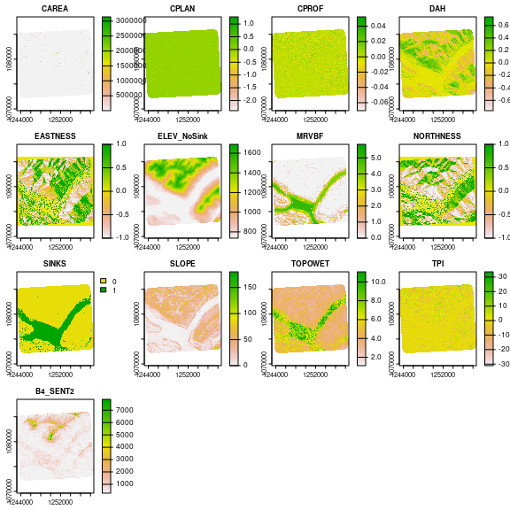

Raster stack of SAGA terrain derivatives and Sentinel-2 Band 4 image.

```r
#Get list of SAGA terrain derivatives within the output directory
raster_list <- list.files(out_dir, "sdat$", full.names = TRUE)

#Drop the filled DEM and ASPECT layers from predictor list, as they are redundant.
raster_list<-raster_list[!raster_list %in%
                           c(file.path(out_dir,'ELEV.sdat'),
                             file.path(out_dir,'ASPECT.sdat'))]

#E.G., Add external Sentinel-2 Band 4 data to the list of raster inputs from wetlandmapR package, this could be any layer
raster_list<-append(raster_list,system.file("extdata", "B4_SENT2.tif", package = "wetlandmapR"))

#Stack all raster inputs using the wetlandmapR 'stack_raster' function, passing 'raster_list' as input, output a raster Look-Up-Table 'rastLUT' CSV
raster_stack <- stack_rasters(rasters = raster_list,
                              target_raster = target_dem,
                              outdir = out_dir,
                              rastLUTfn = out_dir,
                              rastNames = file_path_sans_ext(basename(raster_list)))

#Plot the new stack of raster objects (input layers)
plot(raster_stack)
```

## Attribute raster values to training points …

This code chunck reads in example training points from the wetlandmapR package as a *SpatVector* object with the wetland classes coded by the *T_W_Class_* field. In addition, biogeoclimatic zones (BEC) are loaded internally using the bcmaps package, model outputs will be grouped by this layer by setting it as the *aoi* parameter in the *wetlandmapR::grid_values_at_sp* function. Using the raster stack of predictors plotted above as the *raster_stack* parameter, the *wetlandmapR::grid_values_at_sp* function attributes the intersecting raster values to the training points provided as the *points* parameter. Optionally, the resulting table table can be written to the output directory (*filename*) as a CSV, in this case named *“train_pnts_attributed.csv”*.

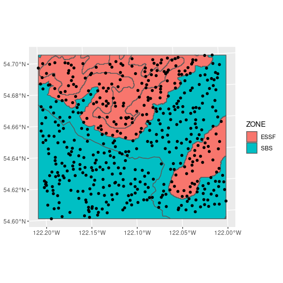

Sample points and BEC-ZONE AOI polygons.

```r
#Load training data as SpatVector
training_points<-vect(system.file('extdata', 'TrainingPnts.shp', package = 'wetlandmapR'))

#Clip training point to extent of the SpatRaster inputs, using sf for this
ext<-ext(raster_stack)
xmin = ext$xmin
xmax = ext$xmax
ymin=ext$ymin
ymax=ext$ymax
ext <- st_sfc(st_polygon(x = list(rbind(c(xmin, ymin), c(xmax, ymin), c(xmax, ymax), c(xmin, ymax), c(xmin, ymin)))), crs = st_crs(training_points))
training_points <- st_intersection(st_as_sf(training_points),ext)


#Load BEC zones from bcmaps
aoi_polys<-bec(ask=F) %>%
  st_crop(training_points)

#Plot AOIs and training points
ggplot()+geom_sf(data=aoi_polys,aes(fill=ZONE))+
  geom_sf(data=training_points)
```

```r
#Convert training_points and aoi_polys to SpatVector
aoi_polys<-vect(aoi_polys)
training_points<-vect(training_points)

#Reproject AOI to CRS of training points
aoi_polys<-project(aoi_polys,crs(training_points))

#Reproject raster_stack to CRS of training points
raster_stack<-project(raster_stack,crs(training_points))

#Assign filepath for output CSV
attributed_csv <- file.path(out_dir,"train_pnts_attributed.csv")



#Attribute training points with intersected input raster values grouped by provided BEC AOI, write results to CSV.
attributed_pnts<-grid_values_at_sp(raster_stack=raster_stack,
                  points=training_points,
                  filename = attributed_csv,
                  aoi = aoi_polys)
```

## Setup predictor list and raster look-up-table (LUT) …

Read in the *rastLUT.csv* file which was output by *wetlandmapR::stack_rasters*, the first column of this CSV contains the file path to each input raster layer, while the second column indicates the name of the layer, and the third column indicates the band index to use. Here we get a list of the raster layer names *predList* from the second column of the *rastLUT* table, and create a new directory for our model outputs within our current output directory.

```r
#Read in rastLUT table as data.frame from the rastLUTfn path provide to 'stack_rasters' above
rastLUT <- read.csv(file.path(out_dir,'rastLUT.csv'),
                    header = FALSE,
                    stringsAsFactors = FALSE)

#View rastLUT table
rastLUT
```

```
##                                                          V1          V2 V3
## 1        /tmp/Rtmpqj6LKr/wetlandmapR_expl/resampl/CAREA.tif       CAREA  1
## 2        /tmp/Rtmpqj6LKr/wetlandmapR_expl/resampl/CPLAN.tif       CPLAN  1
## 3        /tmp/Rtmpqj6LKr/wetlandmapR_expl/resampl/CPROF.tif       CPROF  1
## 4          /tmp/Rtmpqj6LKr/wetlandmapR_expl/resampl/DAH.tif         DAH  1
## 5     /tmp/Rtmpqj6LKr/wetlandmapR_expl/resampl/EASTNESS.tif    EASTNESS  1
## 6  /tmp/Rtmpqj6LKr/wetlandmapR_expl/resampl/ELEV_NoSink.tif ELEV_NoSink  1
## 7        /tmp/Rtmpqj6LKr/wetlandmapR_expl/resampl/MRVBF.tif       MRVBF  1
## 8    /tmp/Rtmpqj6LKr/wetlandmapR_expl/resampl/NORTHNESS.tif   NORTHNESS  1
## 9        /tmp/Rtmpqj6LKr/wetlandmapR_expl/resampl/SINKS.tif       SINKS  1
## 10       /tmp/Rtmpqj6LKr/wetlandmapR_expl/resampl/SLOPE.tif       SLOPE  1
## 11     /tmp/Rtmpqj6LKr/wetlandmapR_expl/resampl/TOPOWET.tif     TOPOWET  1
## 12         /tmp/Rtmpqj6LKr/wetlandmapR_expl/resampl/TPI.tif         TPI  1
## 13    /tmp/Rtmpqj6LKr/wetlandmapR_expl/resampl/B4_SENT2.tif    B4_SENT2  1
```

```r
#Get the list of input predictor names (2nd column)
predList <- rastLUT[,2]


#Create a model output directory called 'output' within 'out_dir' directory
dir.create(file.path(out_dir,"output"))
```

## Run model and diagnostics …

Below we fit a random forest wetland classification model by calling the *wetlandmapR::wetland_model* function using the training data that we attributed with the input raster layers above. We declare the response field to be the “T_W_Class” field, and set *response.type* as categorical. The “ID” field is specified for identifying unique observations. We assign the “BGC_ZONE” column to identify separate AOIs, and a separate classification model is fit for each unique AOI polygon. The *responce.target* parameter is for subsetting the training dataset, in this case we use all wetland categories. We also define the *SINKS* column (input) to be a factor variable. The results include a list containing *model.build* objects output from the [ModelMap](https://cran.r-project.org/web/packages/ModelMap/index.html) package for each AOI. Model outputs will be output to the *model.folder* directory, in this case “output”. Because the modeling process in random, a seed it set for reproducibility.

```r
#Fit a random forest model
model.out <- wetland_model(qdatafn = attributed_csv,
                           model.type = "RF",
                           model.folder = file.path(out_dir,"output"),
                           unique.rowname = "ID",
                           predList = predList,
                           predFactor = c('SINKS'),
                           response.name = "T_W_Class_",
                           response.type = "categorical",
                           seed = 42,
                           response.target = as.vector(unique(training_points$T_W_Class_)),
                           aoi.col = "BGC_ZONE")
```

```
## mtry = 3  OOB error = 2.21%
## Searching left ...
## mtry = 2     OOB error = 2.21%
## 0 0.05
## Searching right ...
## mtry = 6     OOB error = 2.21%
## 0 0.05
```

```
## [1] "LEVELS.pred:  (Wf) Fen Upland"
## [1] "LEVELS.obs:   (Wf) Fen Upland"
```

```
## mtry = 3  OOB error = 17.24%
## Searching left ...
## mtry = 2     OOB error = 16.3%
## 0.05454545 0.05
## mtry = 1     OOB error = 18.18%
## -0.1153846 0.05
## Searching right ...
## mtry = 6     OOB error = 17.55%
## -0.07692308 0.05
```

```
## [1] "LEVELS.pred:  (Fl) Low-bench Floodplain (Wb) Bog (Wf) Fen (Ws) Swamp (Ww) Shallow Water Wetland Upland Water"
## [1] "LEVELS.obs:   (Fl) Low-bench Floodplain (Wb) Bog (Wf) Fen (Ws) Swamp (Ww) Shallow Water Wetland Upland Water"
```

## Create map(s) from model …

Finally we call the *wetlandmapR::wetland_map* function which generates raster prediction surfaces using the model outputs from *wetlandmapR::wetland_model*, i.e., *model.out* for each mdoel / AOI. We point the function to the output directory assigned to *wetland_model* above. We also pass the *rastLUT* data frame, and BEC AOI SpatialPolygons (*aoi*), the AOI column (*aoi.col*) is defined as the *ZONE* column.

```r
#Map random forest results
wetland_map(model.out = model.out,
            model.folder = file.path(out_dir,"output"),
            rastLUTfn = rastLUT,
            aoi = aoi_polys,
            aoi.col = "ZONE")
```

## Plot map results

Plot the output classified ERDAS images by AOI …

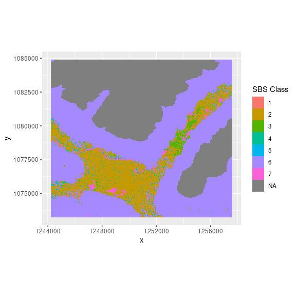

Mapped Classification Results by AOI

```r
#Get .img file paths from temporary directory
SBS.dir<-list.files(paste(tempdir(),'/wetlandmapR_expl/output/',sep=''),pattern = "SBS")
ESSF.dir<-list.files(paste(tempdir(),'/wetlandmapR_expl/output/',sep=''),pattern = "ESSF")
SBS.img<-paste(SBS.dir,'_map.img',sep='')
ESSF.img<-paste(ESSF.dir,'_map.img',sep='')
SBS.key<-paste(SBS.dir,'_map_key.csv',sep='')
ESSF.key<-paste(ESSF.dir,'_map_key.csv',sep='')
#Plot map results for each AOI
ggR(img=raster(paste(tempdir(),'/wetlandmapR_expl/output/',SBS.dir,'/',SBS.img,sep='')),forceCat = T,geom_raster = T)+labs(fill = "SBS Class")
```

```r
SBS_key<-read.csv(paste(tempdir(),'/wetlandmapR_expl/output/',SBS.dir,'/',SBS.key,sep=''))
SBS_key
```

```
##   row                   category integercode
## 1   1  (Fl) Low-bench Floodplain           1
## 2   2                   (Wb) Bog           2
## 3   3                   (Wf) Fen           3
## 4   4                 (Ws) Swamp           4
## 5   5 (Ww) Shallow Water Wetland           5
## 6   6                     Upland           6
## 7   7                      Water           7
```

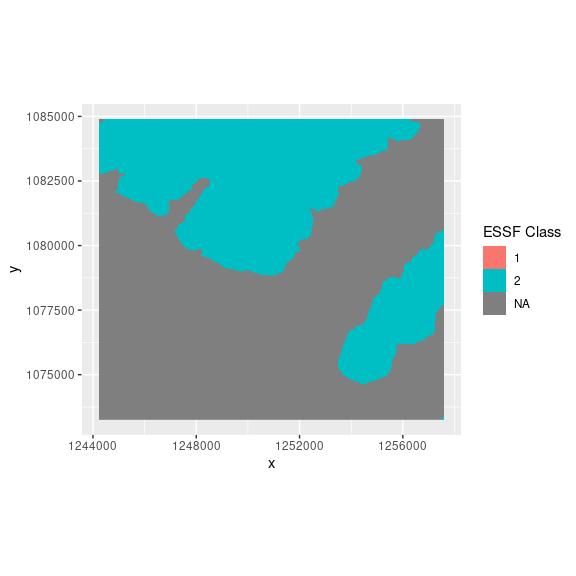

Mapped Classification Results by AOI

```r
ggR(img=raster(paste(tempdir(),'/wetlandmapR_expl/output/',ESSF.dir,'/',ESSF.img,sep='')),forceCat = T,geom_raster = T)+labs(fill = "ESSF Class")
```

```r
ESSF_key<-read.csv(paste(tempdir(),'/wetlandmapR_expl/output/',ESSF.dir,'/',ESSF.key,sep=''))
ESSF_key
```

```
##   row category integercode
## 1   1 (Wf) Fen           1
## 2   2   Upland           2
```

### Polygonize wetland classification map …

```r
#Load the wetland classification map for the SBS BEC Zone as raster object
SBS_classified <- rast(paste(tempdir(),'/wetlandmapR_expl/output/',SBS.dir,'/',SBS.img,sep=''))
#Polygonize wetland classification map
SBS_Class_ply <- raster_to_clean_polygon(r=SBS_classified,min_area_drop_m2=2500,max_area_fill=2500,smooth=T,smooth_method="chaikin",workers=2)
```

```
## Converting raster categories to polygon ...
## Computing polygon areas ...
## Filtering polygons by area ...
## Filling polygon holes and smoothing, may take some time...
```

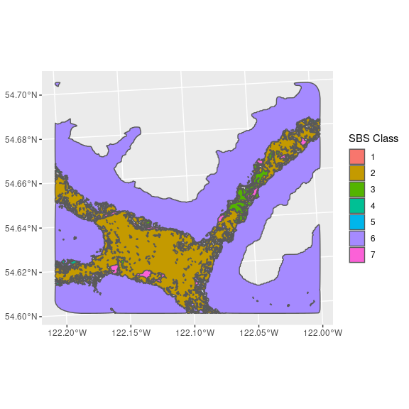

Mapped Classification Results by AOI as simplified polygons

```r
#Plot polygon wetland classification for SBS BEC Zone
ggplot()+
  geom_sf(data = SBS_Class_ply,aes(fill=as.factor(class)))+
  scale_color_brewer(palette = "Spectral")+
  labs(fill = "SBS Class")
```

### Identify high accumulation pour points …

With the classified raster output converted to polygons, pour points for each polygon can be identified using a flow accumulation raster created in RSAGA. This is done by applying the *wetlandmapR::get_low_high_loc* function to each polygon (*poly*) and using the accumulation raster as input (*lyr*), and creating a matrix from the X-Y coordinates returned, along with a unique polygon identifier field *UID*. The *low* parameter return the location of the minimum raster value bounded by the provided polygon when TRUE, and maximum value when set to FALSE.

```r
#Create a flow accumlation layer using RSAGA for target DEM
rsaga.geoprocessor(lib='ta_hydrology',
                          module=29,
                          param = list(DEM=target_dem,
                                       FLOW=file.path(out_dir,'ACC'),
                                       CONVERGENCE=1.1))


#Load the accumulation layer output from `set_grass_env` model as terra raster
acc<-rast(file.path(out_dir,'ACC.sdat'))

#Initialize an empty coordinates vector
low_pnts <- c()
#Populate coordinated vector with coordinates of highest accumulation pixel within each wetland polygon
for(i in 1:nrow(SBS_Class_ply))
{
  low_pnts<-rbind(low_pnts,cbind(get_low_high_loc(lyr=acc,poly=st_geometry(SBS_Class_ply[i,]),low=F),i))
}
```

### Calculate upstream basin statistics …

In the code below the target DEM is hydrologicaly conditioned using the *wetlandmapR::hydro_condition_dem* function. Using the conditioned DEM upstream basins are delineated for the first 20 points in the *low_pnts* table, and zonal statistics computed for each of the input rasters in the *raster_stack*, listed in *rastLUT*, by applying the *wetlandmapR::gen_upstream_basin* and *wetlandmapR::get_basin_stats* functions. The result is a table of upstream basin statistics for each point, identified my a unique ID, which can be used for joining on.

```r
#Hydrologic conditioning of target DEM
hcd<-hydro_condition_dem(dem=target_dem,
                         outdir=tempdir(),
                         env=env)

#Empty vector
upstream_stats<-c()

#For the first 20 pour points in 'low_pnts' calculate upstream basin statistics
for(i in c(1:20))
{
  #Generate a binary grid representing the upstream area for the XY coordinates
  gub<-gen_upstream_basin(dem=hcd,
                          x_coord = low_pnts$x[i],
                          y_coord = low_pnts$y[i],
                          outdir = tempdir(),
                          basin_id = i,
                          env=env)

  #Use the binary upstream grid as a zonal raster, calculate zonal statistics
  basin_stats<-get_basin_stats(zone_rast=gub,
                               statlist= paste(rastLUT$V1,collapse = ';'),
                               outdir=tempdir(),
                               basin_id = i,
                               env=env)

  #Bind new statistics to the upstream_stats matrix
  upstream_stats<-rbind(upstream_stats,basin_stats[2,])


}

head(upstream_stats)
```

```
##    BASIN_BNRY Count.UCU CAREAN CAREAMIN   CAREAMAX  CAREAMEAN CARESTDDEV
## 2           1       940    940 687.0812 602307.562 18824.2295 53116.1748
## 21          1         9      9 625.0000   6957.536  2235.1785  2054.2504
## 22          1         2      2 698.2209   1075.150   886.6857   266.5294
## 23          1         4      4 625.0000   2101.612  1246.3166   742.4351
## 24          1       314    314 625.0000 158476.969  7438.1244 22383.6026
## 25          1         1      1 842.5550    842.555   842.5550         NA
##        CAREASUM CPLANN  CPLANMIN CPLANMAX CPLANMEAN CPLASTDDEV  CPLANSUM CPROFN
## 2  17694775.766    940 -0.115129 0.081755 -0.000456   0.016464 -0.428705    940
## 21    20116.606      9 -0.084853 0.000000 -0.023370   0.031711 -0.210327      9
## 22     1773.371      2 -0.021466 0.050088  0.014311   0.050596  0.028622      2
## 23     4985.266      4 -0.028622 0.042426 -0.001915   0.031965 -0.007662      4
## 24  2335571.048    314 -0.320000 0.320000  0.001551   0.054758  0.486983    314
## 25      842.555      1  0.000000 0.000000  0.000000         NA  0.000000      1
##     CPROFMIN CPROFMAX CPROFMEAN CPROSTDDEV  CPROFSUM DAHN    DAHMIN    DAHMAX
```

[output cut: 69 more lines]